# Classification

## k-Nearest Neighbor

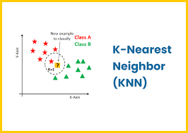

kNN (image source:https://www.trivusi.web.id/2022/06/algoritma-knn.html)

```r
knnFit <- train(Kelayakan.Keringanan.UKT ~ ., data = training, method = "knn", trControl = ctrl, preProcess = c("center","scale"), tuneLength = 20)
knnFit
```

```
## k-Nearest Neighbors
##
## 76 samples
##  5 predictor
##  2 classes: 'yes', 'no'
##
## Pre-processing: centered (11), scaled (11)
## Resampling: Cross-Validated (10 fold, repeated 3 times)
## Summary of sample sizes: 69, 69, 68, 68, 68, 68, ...
## Resampling results across tuning parameters:
##
##   k   Accuracy   Kappa
##    5  0.8744048  0.7352010
##    7  0.8779762  0.7435909
##    9  0.8869048  0.7642059
##   11  0.8952381  0.7912547
##   13  0.8142857  0.5851479
##   15  0.7958333  0.5281321
##   17  0.7863095  0.5062614
##   19  0.7339286  0.3931931
##   21  0.6583333  0.2005010
##   23  0.6982143  0.3002106
##   25  0.7482143  0.4489953
##   27  0.8083333  0.5692318
##   29  0.8815476  0.7596576
##   31  0.8952381  0.7874692
##   33  0.8166667  0.5570379
##   35  0.7196429  0.2649317
##   37  0.7136905  0.2564594
##   39  0.7190476  0.2721128
##   41  0.7648810  0.3699573
##   43  0.7666667  0.3936160
##
## Accuracy was used to select the optimal model using the largest value.
## The final value used for the model was k = 31.
```

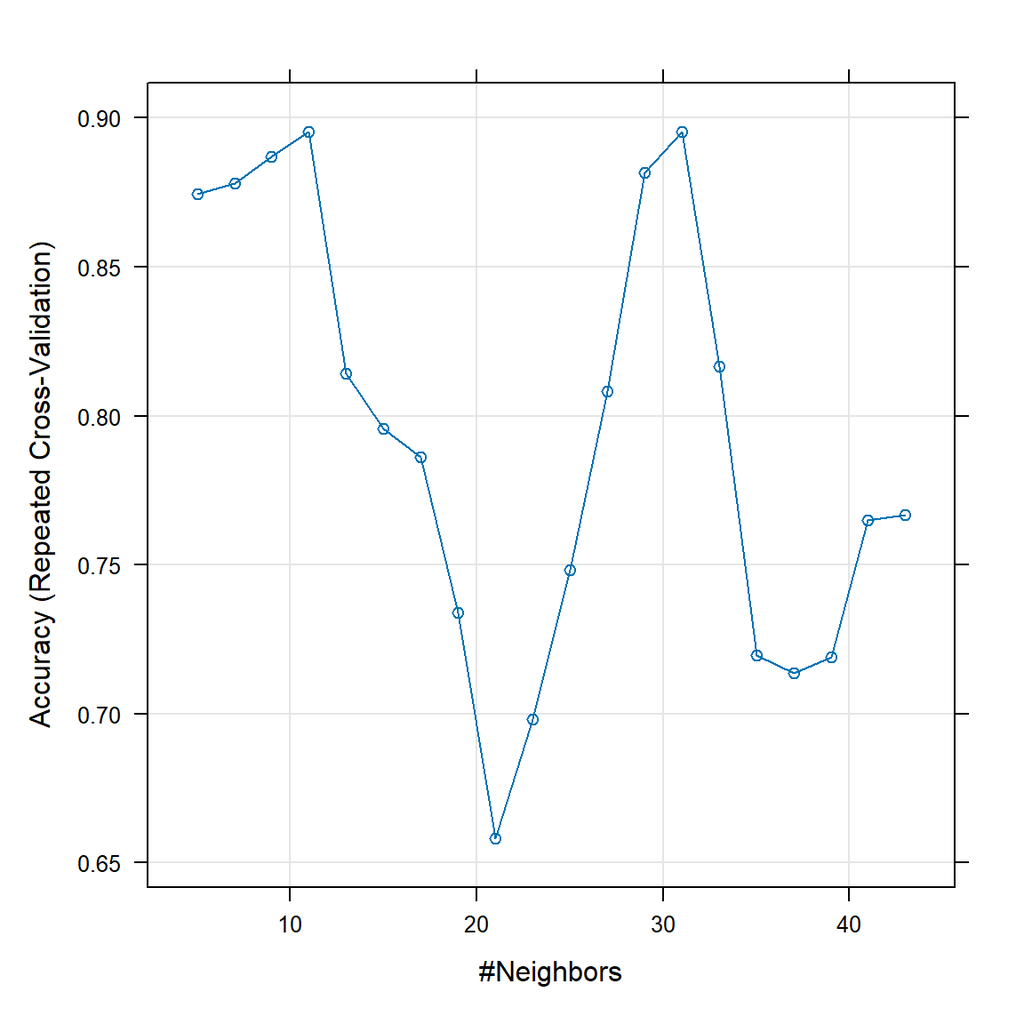

```r
plot(knnFit)
```

```r
knnPredict <- predict(knnFit,newdata = testing )
```

Kita bisa melihat kebaikan model dengan melihat Confusion Matrix dari hasil prediksi model tersebut.

```r
confusionMatrix(knnPredict, testing$Kelayakan.Keringanan.UKT)
```

```
## Confusion Matrix and Statistics
##
##           Reference
## Prediction yes no
##        yes   7  1
##        no    1 15
##
##                Accuracy : 0.9167
##                  95% CI : (0.73, 0.9897)
##     No Information Rate : 0.6667
##     P-Value [Acc > NIR] : 0.004871
##
##                   Kappa : 0.8125
##
##  Mcnemar's Test P-Value : 1.000000
##
##             Sensitivity : 0.8750
##             Specificity : 0.9375
##          Pos Pred Value : 0.8750
##          Neg Pred Value : 0.9375
##              Prevalence : 0.3333
##          Detection Rate : 0.2917
##    Detection Prevalence : 0.3333
##       Balanced Accuracy : 0.9062
##
##        'Positive' Class : yes
##
```

```r
mean(knnPredict == testing$Kelayakan.Keringanan.UKT)
```

```
## [1] 0.9166667
```

Dari hasil di atas, terlihat bahwa model k-NN punya akurasi sebesar 91.67% pada data testing dan dapat memprediksi dengan baik di mana 7 kategori yes terprediksi dengan benar dan 1 kategori yes terprediksi dengan salah. Sedangkan 15 kategori no terprediksi dengan benar dan 1 kategori no terprediksi dengan salah.

## Naive Bayes

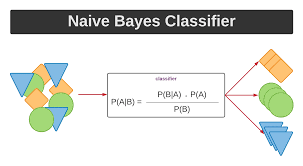

Naive Bayes (image source: https://pemrogramanmatlab.com/2023/08/09/memahami-algoritma-naive-bayes-konsep-dan-penerapan/)

```r
NBFit <- train(Kelayakan.Keringanan.UKT ~ ., data = training, method = "naive_bayes", trControl = ctrl, preProcess = c("center","scale"), tuneLength = 20)
NBFit
```

```
## Naive Bayes
##
## 76 samples
##  5 predictor
##  2 classes: 'yes', 'no'
##
## Pre-processing: centered (11), scaled (11)
## Resampling: Cross-Validated (10 fold, repeated 3 times)
## Summary of sample sizes: 68, 68, 69, 68, 68, 69, ...
## Resampling results across tuning parameters:
##
##   usekernel  Accuracy   Kappa
##   FALSE      0.7875000  0.5924711
##    TRUE      0.9071429  0.8075333
##
## Tuning parameter 'laplace' was held constant at a value of 0
## Tuning
##  parameter 'adjust' was held constant at a value of 1
## Accuracy was used to select the optimal model using the largest value.
## The final values used for the model were laplace = 0, usekernel = TRUE
##  and adjust = 1.
```

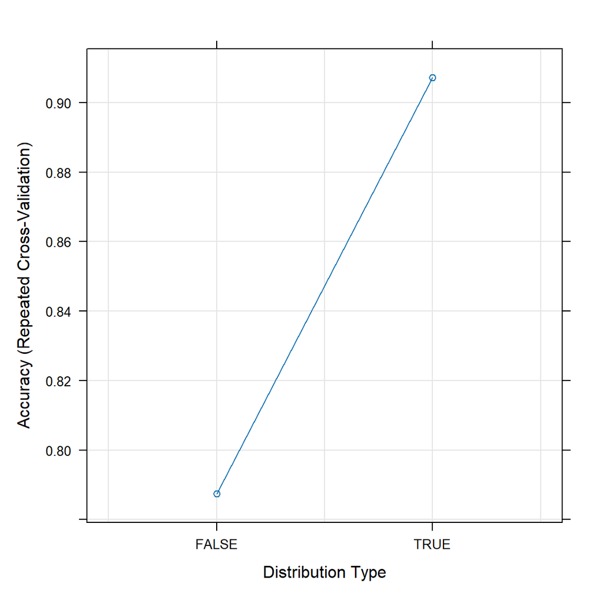

```r
plot(NBFit)
```

Dari hasil di atas, kita bisa simpulkan bahwa model Naive Bayes dengan kernel punya akurasi yang lebih tinggi dibandingkan model tanpa kernel.

```r
NBPredict <- predict(NBFit,newdata = testing)
```

Kita bisa melihat kebaikan model dengan melihat Confusion Matrix dari hasil prediksi model tersebut.

```r
confusionMatrix(NBPredict, testing$Kelayakan.Keringanan.UKT)
```

```
## Confusion Matrix and Statistics
##
##           Reference
## Prediction yes no
##        yes   7  1
##        no    1 15
##
##                Accuracy : 0.9167
##                  95% CI : (0.73, 0.9897)
##     No Information Rate : 0.6667
##     P-Value [Acc > NIR] : 0.004871
##
##                   Kappa : 0.8125
##
##  Mcnemar's Test P-Value : 1.000000
##
##             Sensitivity : 0.8750
##             Specificity : 0.9375
##          Pos Pred Value : 0.8750
##          Neg Pred Value : 0.9375
##              Prevalence : 0.3333
##          Detection Rate : 0.2917
##    Detection Prevalence : 0.3333
##       Balanced Accuracy : 0.9062
##
##        'Positive' Class : yes
##
```

```r
mean(NBPredict == testing$Kelayakan.Keringanan.UKT)
```

```
## [1] 0.9166667
```

Dari hasil di atas, terlihat bahwa model Naive Bayes punya akurasi sebesar 91.67% pada data testing dan dapat memprediksi dengan baik di mana 7 kategori yes terprediksi dengan benar dan 1 kategori yes terprediksi dengan salah. Sedangkan 15 kategori no terprediksi dengan benar dan 1 kategori no terprediksi dengan salah.

# 4. Evaluasi

```r
models_compares <- resamples(list(kNN = knnFit, Naive_Bayes = NBFit))

# Ringkasan models performances
summary(models_compares)
```

```
##
## Call:
## summary.resamples(object = models_compares)
##
## Models: kNN, Naive_Bayes
## Number of resamples: 30
##
## Accuracy
##                  Min.   1st Qu. Median      Mean 3rd Qu. Max. NA's
## kNN         0.4285714 0.8750000 0.9375 0.8952381       1    1    0
## Naive_Bayes 0.7142857 0.8616071 0.8750 0.9071429       1    1    0
##
## Kappa
##                    Min.   1st Qu. Median      Mean 3rd Qu. Max. NA's
## kNN         -0.07692308 0.7142857  0.875 0.7874692       1    1    0
## Naive_Bayes  0.30000000 0.7003106  0.750 0.8075333       1    1    0
```

Dari perbandingan ini, kita bisa simpulkan bahwa berdasarkan nilai akurasi dan Kappa tertinggi, model Naive Bayes lebih baik dari k-NN dapat memprediksi kategori kelayakan penerimaan keringanan UKT kuliah.